# Supervised Learning - Foundations Project: ReCell

## EDA

- It is a good idea to explore the data once again after manipulating it.

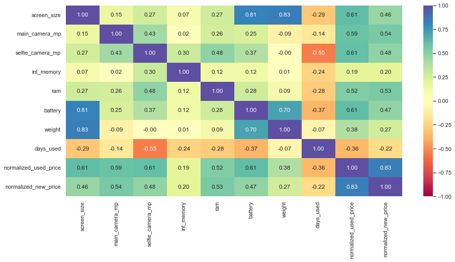

```python
# Corellation analysis of the variables

cols_list = df.select_dtypes(include=np.number).columns.tolist()
# dropping release_year as it is a temporal variable
cols_list.remove("release_year")

plt.figure(figsize=(15, 7))
sns.heatmap(
    df[cols_list].corr(), annot=True, vmin=-1, vmax=1, fmt=".2f", cmap="Spectral"
)
plt.show()
```

Observations: The attributes of used phone devices affecting normalized used price still remain the same (screen size, selfie camera size, main camera size and battery.

```python
# function to create labeled barplots


def labeled_barplot(data, feature, perc=False, n=None):
    """
    Barplot with percentage at the top

    data: dataframe
    feature: dataframe column
    perc: whether to display percentages instead of count (default is False)
    n: displays the top n category levels (default is None, i.e., display all levels)
    """

    total = len(data[feature])  # length of the column
    count = data[feature].nunique()
    if n is None:
        plt.figure(figsize=(count + 2, 6))
    else:
        plt.figure(figsize=(n + 2, 6))

    plt.xticks(rotation=90, fontsize=15)
    ax = sns.countplot(
        data=data,
        x=feature,
        palette="Paired",
        order=data[feature].value_counts().index[:n],
    )

    for p in ax.patches:
        if perc == True:
            label = "{:.1f}%".format(
                100 * p.get_height() / total
            )  # percentage of each class of the category
        else:
            label = p.get_height()  # count of each level of the category

        x = p.get_x() + p.get_width() / 2  # width of the plot
        y = p.get_height()  # height of the plot

        ax.annotate(
            label,
            (x, y),
            ha="center",
            va="center",
            size=12,
            xytext=(0, 5),
            textcoords="offset points",
        )  # annotate the percentage

    plt.show()  # show the plot
```

```python
def histogram_boxplot(data, feature, figsize=(15, 10), kde=False, bins=None):
    """
    Boxplot and histogram combined

    data: dataframe
    feature: dataframe column
    figsize: size of figure (default (15,10))
    kde: whether to show the density curve (default False)
    bins: number of bins for histogram (default None)
    """
    f2, (ax_box2, ax_hist2) = plt.subplots(
        nrows=2,  # Number of rows of the subplot grid= 2
        sharex=True,  # x-axis will be shared among all subplots
        gridspec_kw={"height_ratios": (0.25, 0.75)},
        figsize=figsize,
    )  # creating the 2 subplots
    sns.boxplot(
        data=data, x=feature, ax=ax_box2, showmeans=True, color="violet"
    )  # boxplot will be created and a triangle will indicate the mean value of the column
    sns.histplot(
        data=data, x=feature, kde=kde, ax=ax_hist2, bins=bins
    ) if bins else sns.histplot(
        data=data, x=feature, kde=kde, ax=ax_hist2
    )  # For histogram
    ax_hist2.axvline(
        data[feature].mean(), color="green", linestyle="--"
    )  # Add mean to the histogram
    ax_hist2.axvline(
        data[feature].median(), color="black", linestyle="-"
    )  # Add median to the histogram
```

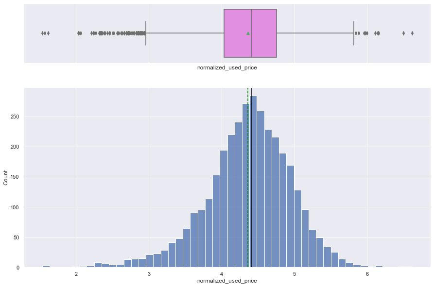

```python
# Histogram and box plot for normalised used price

histogram_boxplot(df1, "normalized_used_price", bins=50)
```

Observations: The data is normally distributed

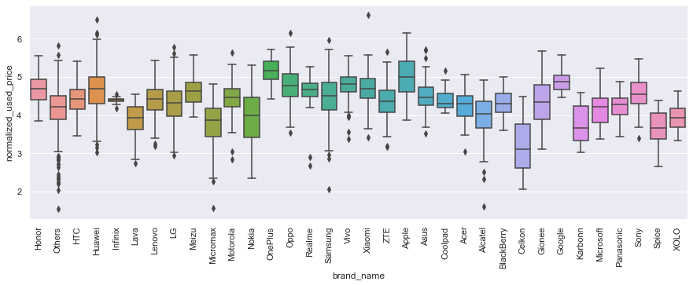

```python
# Box plots of used devices brand names
plt.figure(figsize=(15, 5))
sns.boxplot(data=df1, y="normalized_used_price", x="brand_name")
plt.xticks(rotation=90)
plt.show()
```

Observations: There are used priced variations across brands

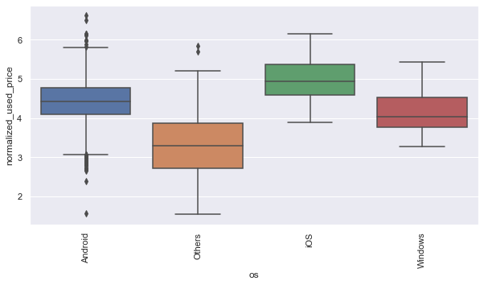

```python
# Box plots for OS
plt.figure(figsize=(10, 5))
sns.boxplot(data=df1, y="normalized_used_price", x="os")
plt.xticks(rotation=90)
plt.show()
```

Observations: The median used price for iOS is higher than for android and windows device

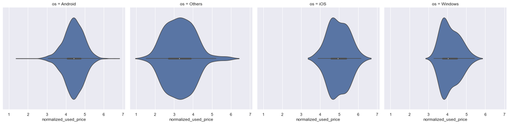

```python
# Dispersion of normalized used price for every OS
sns.catplot(x='normalized_used_price',
            col='os',
            data=data,
            col_wrap=4,
            kind="violin")
plt.show()
```

Observations: The normalized used price for other OS has least price compared to others

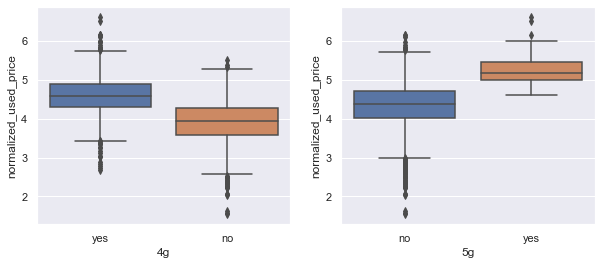

```python
# Box plots for normalized used prices and 4G/5G
plt.figure(figsize=(10, 4))

plt.subplot(121)
sns.boxplot(data=df, x="4g", y="normalized_used_price")

plt.subplot(122)
sns.boxplot(data=df, x="5g", y="normalized_used_price")

plt.show()
```

Observations: Devices with 5G command higher normalized used prices compared to those with 4G

```python
# creating a copy of the data
df1 = df.copy()
```

```python
# this will help in making the Python code more structured automatically (good coding practice)


# Libraries to help with reading and manipulating data
import numpy as np
import pandas as pd

# Libraries to help with data visualization
import matplotlib.pyplot as plt
import seaborn as sns

sns.set()

# split the data into train and test
from sklearn.model_selection import train_test_split

# to build linear regression_model
from sklearn.linear_model import LinearRegression

# to check model performance
from sklearn.metrics import mean_absolute_error, mean_squared_error, r2_score

# to build linear regression_model using statsmodels
import statsmodels.api as sm

# to compute VIF
from statsmodels.stats.outliers_influence import variance_inflation_factor
```

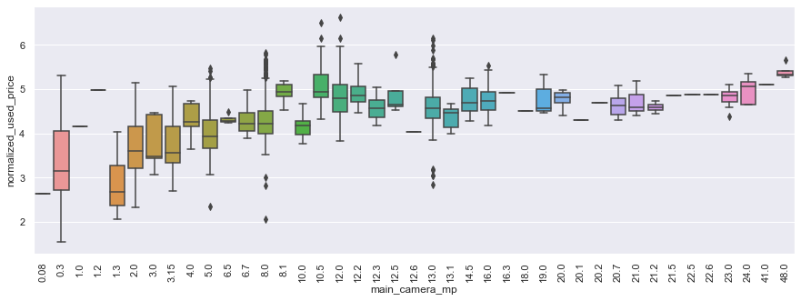

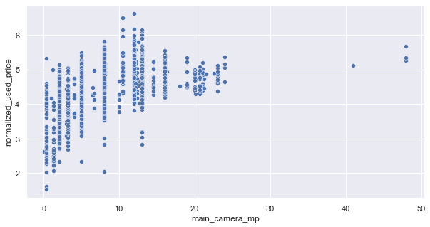

```python
# scatter plot of normalised used price and main camera MP
plt.figure(figsize=(15, 5))
sns.boxplot(data=df1, y="normalized_used_price", x="main_camera_mp")
plt.xticks(rotation=90)
plt.show()

plt.figure(figsize=(10,5))
sns.scatterplot(data=data,x='main_camera_mp',y='normalized_used_price')
plt.show()
```

Observations: Box and scatter plots of effect of main camera MP size changes on normalised used price of used devices. Increase in main camera MP size led to increased normalized used prices

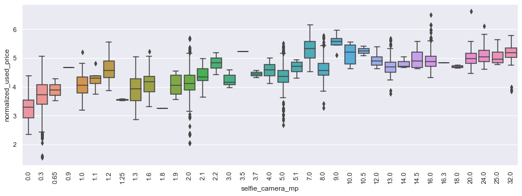

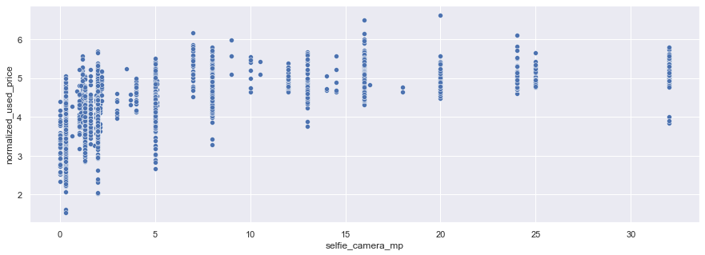

```python
# Box and scatter plots for normalized used price and selfie camera MP
plt.figure(figsize=(15, 5))
sns.boxplot(data=df1, y="normalized_used_price", x="selfie_camera_mp")
plt.xticks(rotation=90)
plt.show()

plt.figure(figsize=(15,5))
sns.scatterplot(data=data,x='selfie_camera_mp',y='normalized_used_price')
plt.show()
```

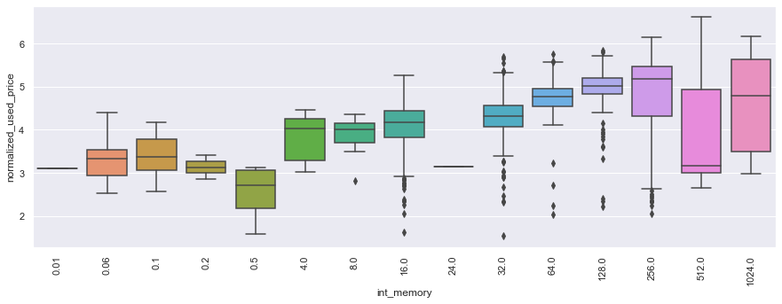

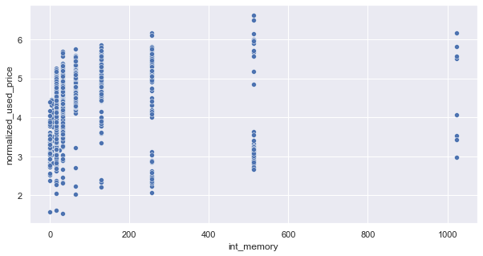

```python
# Box and scatter plots for normalized used price and internal memory
plt.figure(figsize=(15, 5))
sns.boxplot(data=df1, y="normalized_used_price", x="int_memory")
plt.xticks(rotation=90)
plt.show()

plt.figure(figsize=(10,5))
sns.scatterplot(data=data,x='int_memory',y='normalized_used_price')
plt.show()
```

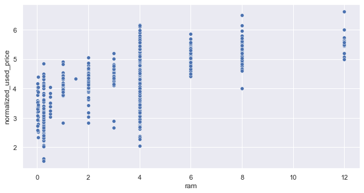

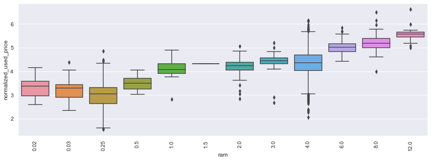

```python
# Box and scatter plots for normalized used price and RAM size
plt.figure(figsize=(10,5))
sns.scatterplot(data=data,x='ram',y='normalized_used_price')
plt.show()

plt.figure(figsize=(15, 5))
sns.boxplot(data=df1, y="normalized_used_price", x="ram")
plt.xticks(rotation=90)
plt.show()
```

Observations: Scatter and box plots of effect of RAM size changes on normalised used price of used devices. Increase in RAM size led to increased normalized used prices

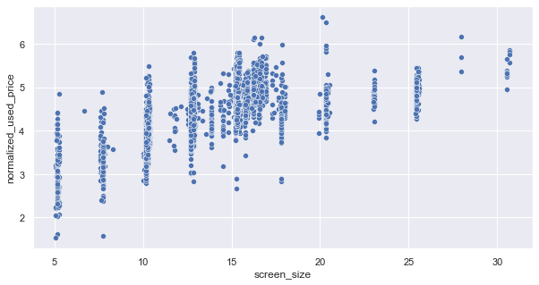

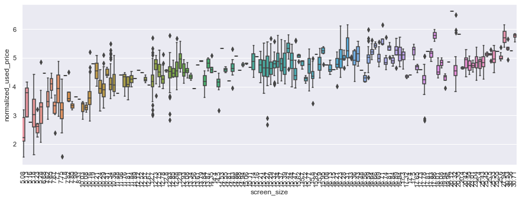

```python
# scatter plot of total time and the cost of the order

plt.figure(figsize=(10,5))
sns.scatterplot(data=data,x='screen_size',y='normalized_used_price')
plt.show()

plt.figure(figsize=(15, 5))
sns.boxplot(data=df1, y="normalized_used_price", x="screen_size")
plt.xticks(rotation=90)
plt.show()
```

```python
Observations: Scatter plot of effect of screen size changes on normalised used price of used devices.
            Increase in screen size led to oincreased normalized used prices
```

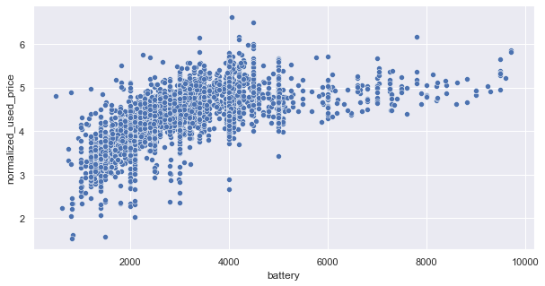

```python
# scatter plot of normalised used price and battery

plt.figure(figsize=(10,5))
sns.scatterplot(data=data,x='battery',y='normalized_used_price')
plt.show()
```

Observations: Scatter plot of effect of battery size changes on normalised used price of used devices. Increase in battery size led to oincreased normalized used prices

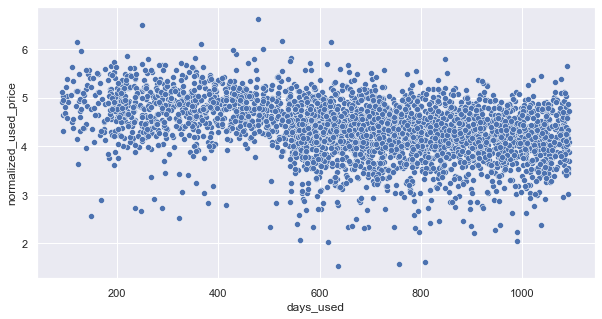

```python
# scatter plot of normalised used price and days used
plt.figure(figsize=(10,5))
sns.scatterplot(data=data,x='days_used',y='normalized_used_price')
plt.show()

screen_size
```

Observations:Scatter plot of effect of days used changes on normalised used price of used devices.

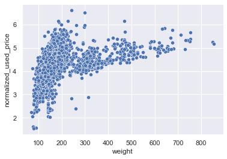

```python
# scatter plot of normalised used price and weightbattery
# plt.figure(figsize=(15,20))
sns.scatterplot(data=data,x='weight',y='normalized_used_price')
plt.show()
```

Observations: Scatter plot of effect of weight changes on normalised used price of used devices. Increase in weight increases the normalized used price of devices

# Feature Engineering

Let's create a new column years_since_release from the release_year column. We will consider the year of data collection, 2021, as the baseline. We will drop the release_year column.

```python
df1["years_since_release"] = 2021 - df1["release_year"]
df1.drop("release_year", axis=1, inplace=True)
df1["years_since_release"].describe()
```

```
count    3454.000000
mean        5.034742
std         2.298455
min         1.000000
25%         3.000000
50%         5.500000
75%         7.000000
max         8.000000
Name: years_since_release, dtype: float64
```

Observations: This is the summary of the number of years of used devices since being released

# Outlier Check

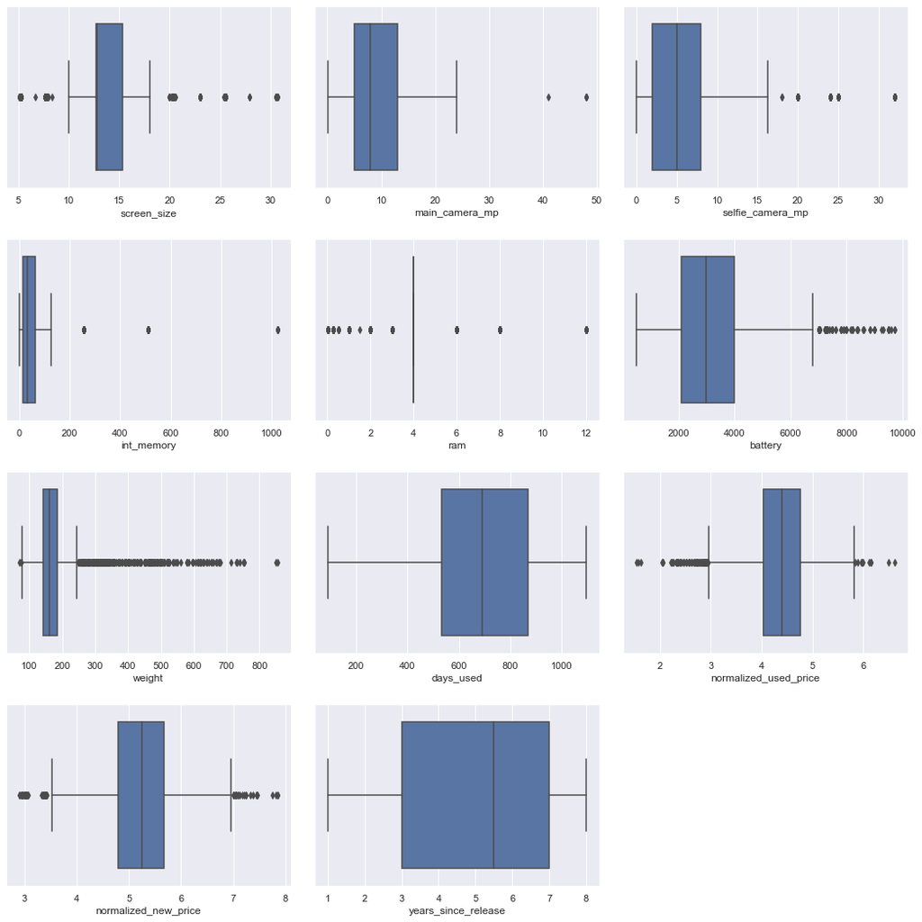

```python
# outlier detection using boxplot
num_cols = df1.select_dtypes(include=np.number).columns.tolist()

plt.figure(figsize=(15, 15))

for i, variable in enumerate(num_cols):
    plt.subplot(4, 3, i + 1)
    sns.boxplot(data=df1, x=variable)
    plt.tight_layout(pad=2)

plt.show()
```

Observations: - There are quite a few outliers in the data - However, we will not treat them as they are proper values

Data Preparation for modeling

We want to predict the normalized price of used devices Before we proceed to build a model, we'll have to encode categorical features We'll split the data into train and test to be able to evaluate the model that we build on the train data We will build a Linear Regression model using the train data and then check it's performance

```python
# Libraries to help with reading and manipulating data
import numpy as np
import pandas as pd

# Libraries to help with data visualization
import matplotlib.pyplot as plt
import seaborn as sns

sns.set()

# split the data into train and test
from sklearn.model_selection import train_test_split

# to build linear regression_model
from sklearn.linear_model import LinearRegression

# to check model performance
from sklearn.metrics import mean_absolute_error, mean_squared_error, r2_score

# to build linear regression_model using statsmodels
import statsmodels.api as sm

# to compute VIF
from statsmodels.stats.outliers_influence import variance_inflation_factor
import statsmodels.api as sm
```

```python
# defining X and y variables
X = df1.drop(["normalized_used_price"], axis=1)
y = df1["normalized_used_price"]

print(X.head())
print(y.head())
```

```
  brand_name       os  screen_size   4g   5g  main_camera_mp  \
0      Honor  Android        14.50  yes   no            13.0
1      Honor  Android        17.30  yes  yes            13.0
2      Honor  Android        16.69  yes  yes            13.0
3      Honor  Android        25.50  yes  yes            13.0
4      Honor  Android        15.32  yes   no            13.0

   selfie_camera_mp  int_memory  ram  battery  weight  days_used  \
0               5.0        64.0  3.0   3020.0   146.0        127
1              16.0       128.0  8.0   4300.0   213.0        325
2               8.0       128.0  8.0   4200.0   213.0        162
3               8.0        64.0  6.0   7250.0   480.0        345
4               8.0        64.0  3.0   5000.0   185.0        293

   normalized_new_price  years_since_release
0              4.715100                    1
1              5.519018                    1
2              5.884631                    1
3              5.630961                    1
4              4.947837                    1
0    4.307572
1    5.162097
2    5.111084
3    5.135387
4    4.389995
Name: normalized_used_price, dtype: float64
```

```python
X.head()
```

[output not shown]

```python
# adding the intercept to data
X = sm.add_constant(X)
```

```python
# creating dummy variables
X = pd.get_dummies(
    X,
    columns=X.select_dtypes(include=["object", "category"]).columns.tolist(),
    drop_first=True,
)  ## Complete the code to create dummies for independent features

X.head()
```

|  | const | screen_size | main_camera_mp | selfie_camera_mp | int_memory | ram | battery | weight | days_used | normalized_new_price | ... | brand_name_Spice | brand_name_Vivo | brand_name_XOLO | brand_name_Xiaomi | brand_name_ZTE | os_Others | os_Windows | os_iOS | 4g_yes | 5g_yes |
| --- | --- | --- | --- | --- | --- | --- | --- | --- | --- | --- | --- | --- | --- | --- | --- | --- | --- | --- | --- | --- | --- |
| 0 | 1.0 | 14.50 | 13.0 | 5.0 | 64.0 | 3.0 | 3020.0 | 146.0 | 127 | 4.715100 | ... | 0 | 0 | 0 | 0 | 0 | 0 | 0 | 0 | 1 | 0 |
| 1 | 1.0 | 17.30 | 13.0 | 16.0 | 128.0 | 8.0 | 4300.0 | 213.0 | 325 | 5.519018 | ... | 0 | 0 | 0 | 0 | 0 | 0 | 0 | 0 | 1 | 1 |
| 2 | 1.0 | 16.69 | 13.0 | 8.0 | 128.0 | 8.0 | 4200.0 | 213.0 | 162 | 5.884631 | ... | 0 | 0 | 0 | 0 | 0 | 0 | 0 | 0 | 1 | 1 |
| 3 | 1.0 | 25.50 | 13.0 | 8.0 | 64.0 | 6.0 | 7250.0 | 480.0 | 345 | 5.630961 | ... | 0 | 0 | 0 | 0 | 0 | 0 | 0 | 0 | 1 | 1 |
| 4 | 1.0 | 15.32 | 13.0 | 8.0 | 64.0 | 3.0 | 5000.0 | 185.0 | 293 | 4.947837 | ... | 0 | 0 | 0 | 0 | 0 | 0 | 0 | 0 | 1 | 0 |

5 rows × 49 columns

```python
# splitting the data in 70:30 ratio for train to test data

x_train, x_test, y_train, y_test = train_test_split(X, y, test_size=0.3, random_state=1)
```

```python
print("Number of rows in train data =", x_train.shape[0])
print("Number of rows in test data =", x_test.shape[0])
```

```
Number of rows in train data = 2417
Number of rows in test data = 1037
```

## Model Building - Linear Regression

```python
# checking if test data still has missing values
x_test.isna().sum()
```

```
const                     0
screen_size               0
main_camera_mp           50
selfie_camera_mp          1
int_memory                1
ram                       2
battery                   2
weight                    0
days_used                 0
normalized_new_price      0
years_since_release       0
brand_name_Alcatel        0
brand_name_Apple          0
brand_name_Asus           0
brand_name_BlackBerry     0
brand_name_Celkon         0
brand_name_Coolpad        0
brand_name_Gionee         0
brand_name_Google         0
brand_name_HTC            0
brand_name_Honor          0
brand_name_Huawei         0
brand_name_Infinix        0
brand_name_Karbonn        0
brand_name_LG             0
brand_name_Lava           0
brand_name_Lenovo         0
brand_name_Meizu          0
brand_name_Micromax       0
brand_name_Microsoft      0
brand_name_Motorola       0
brand_name_Nokia          0
brand_name_OnePlus        0
brand_name_Oppo           0
brand_name_Others         0
brand_name_Panasonic      0
brand_name_Realme         0
brand_name_Samsung        0
brand_name_Sony           0
brand_name_Spice          0
brand_name_Vivo           0
brand_name_XOLO           0
brand_name_Xiaomi         0
brand_name_ZTE            0
os_Others                 0
os_Windows                0
os_iOS                    0
4g_yes                    0
5g_yes                    0
dtype: int64
```

```python
# Filling missing training data using column median values and then checking status of missing values
#x_train["main_camera_mp"] = x_train["main_camera_mp"].fillna(df1["main_camera_mp"].median)
x_train[["main_camera_mp","selfie_camera_mp","int_memory","ram","battery","weight"]] = x_train[["main_camera_mp","selfie_camera_mp","int_memory","ram","battery","weight"]].fillna(df1[["main_camera_mp","selfie_camera_mp","int_memory","ram","battery","weight"]].median())
#olsmodel = sm.OLS(y_train, x_train).fit()
#print(olsmodel.summary())
x_train.isnull().sum()
```

```
const                    0
screen_size              0
main_camera_mp           0
selfie_camera_mp         0
int_memory               0
ram                      0
battery                  0
weight                   0
days_used                0
normalized_new_price     0
years_since_release      0
brand_name_Alcatel       0
brand_name_Apple         0
brand_name_Asus          0
brand_name_BlackBerry    0
brand_name_Celkon        0
brand_name_Coolpad       0
brand_name_Gionee        0
brand_name_Google        0
brand_name_HTC           0
brand_name_Honor         0
brand_name_Huawei        0
brand_name_Infinix       0
brand_name_Karbonn       0
brand_name_LG            0
brand_name_Lava          0
brand_name_Lenovo        0
brand_name_Meizu         0
brand_name_Micromax      0
brand_name_Microsoft     0
brand_name_Motorola      0
brand_name_Nokia         0
brand_name_OnePlus       0
brand_name_Oppo          0
brand_name_Others        0
brand_name_Panasonic     0
brand_name_Realme        0
brand_name_Samsung       0
brand_name_Sony          0
brand_name_Spice         0
brand_name_Vivo          0
brand_name_XOLO          0
brand_name_Xiaomi        0
brand_name_ZTE           0
os_Others                0
os_Windows               0
os_iOS                   0
4g_yes                   0
5g_yes                   0
dtype: int64
```

```python
x_test[["main_camera_mp","selfie_camera_mp","int_memory","ram","battery","weight"]] = x_test[["main_camera_mp","selfie_camera_mp","int_memory","ram","battery","weight"]].fillna(df1[["main_camera_mp","selfie_camera_mp","int_memory","ram","battery","weight"]].median())
#olsmodel = sm.OLS(y_train, x_train).fit()
```

```python
## Code to fill all missing data with column median value
#df = df.fillna(df.median())
```

```python
olsmodel = sm.OLS(y_train, x_train).fit()
print(olsmodel.summary())
```

```
                              OLS Regression Results
=================================================================================
Dep. Variable:     normalized_used_price   R-squared:                       0.845
Model:                               OLS   Adj. R-squared:                  0.842
Method:                    Least Squares   F-statistic:                     268.8
Date:                   Fri, 23 Feb 2024   Prob (F-statistic):               0.00
Time:                           09:57:49   Log-Likelihood:                 124.22
No. Observations:                   2417   AIC:                            -150.4
Df Residuals:                       2368   BIC:                             133.3
Df Model:                             48
Covariance Type:               nonrobust
=========================================================================================
                            coef    std err          t      P>|t|      [0.025      0.975]
-----------------------------------------------------------------------------------------
const                     1.3286      0.071     18.604      0.000       1.189       1.469
screen_size               0.0243      0.003      7.145      0.000       0.018       0.031
main_camera_mp            0.0203      0.001     13.806      0.000       0.017       0.023
selfie_camera_mp          0.0136      0.001     12.084      0.000       0.011       0.016
int_memory                0.0001   6.97e-05      1.542      0.123   -2.92e-05       0.000
ram                       0.0239      0.005      4.657      0.000       0.014       0.034
battery               -1.585e-05   7.27e-06     -2.181      0.029   -3.01e-05    -1.6e-06
weight                    0.0010      0.000      7.421      0.000       0.001       0.001
days_used              3.485e-05   3.09e-05      1.127      0.260   -2.58e-05    9.55e-05
normalized_new_price      0.4310      0.012     35.133      0.000       0.407       0.455
years_since_release      -0.0248      0.005     -5.441      0.000      -0.034      -0.016
brand_name_Alcatel        0.0153      0.048      0.321      0.748      -0.078       0.109
brand_name_Apple         -0.0116      0.147     -0.079      0.937      -0.300       0.277
brand_name_Asus           0.0195      0.048      0.408      0.683      -0.074       0.113
brand_name_BlackBerry    -0.0295      0.070     -0.420      0.675      -0.167       0.108
brand_name_Celkon        -0.0424      0.066     -0.640      0.522      -0.172       0.088
brand_name_Coolpad        0.0401      0.073      0.551      0.582      -0.103       0.183
brand_name_Gionee         0.0454      0.058      0.787      0.431      -0.068       0.159
brand_name_Google        -0.0312      0.085     -0.369      0.712      -0.197       0.135
brand_name_HTC           -0.0115      0.048     -0.240      0.811      -0.106       0.083
brand_name_Honor          0.0244      0.049      0.496      0.620      -0.072       0.121
brand_name_Huawei        -0.0081      0.044     -0.181      0.856      -0.095       0.079
brand_name_Infinix        0.1548      0.093      1.661      0.097      -0.028       0.337
brand_name_Karbonn        0.0971      0.067      1.447      0.148      -0.034       0.229
brand_name_LG            -0.0152      0.045     -0.335      0.738      -0.104       0.074
brand_name_Lava           0.0337      0.062      0.541      0.589      -0.089       0.156
```

[output cut: 19 more lines]

```
os_Windows               -0.0176      0.045     -0.389      0.697      -0.106       0.071
os_iOS                   -0.0585      0.146     -0.399      0.690      -0.346       0.229
4g_yes                    0.0507      0.016      3.190      0.001       0.020       0.082
5g_yes                   -0.0435      0.032     -1.369      0.171      -0.106       0.019
==============================================================================
Omnibus:                      217.620   Durbin-Watson:                   1.904
Prob(Omnibus):                  0.000   Jarque-Bera (JB):              409.702
Skew:                          -0.607   Prob(JB):                     1.08e-89
Kurtosis:                       4.611   Cond. No.                     1.78e+05
==============================================================================

Notes:
[1] Standard Errors assume that the covariance matrix of the errors is correctly specified.
[2] The condition number is large, 1.78e+05. This might indicate that there are
strong multicollinearity or other numerical problems.
```

Observations: - R squared value is 0.845 which is good. - Adjusted R squared value is 0.842 which is good fit as it is high. - The value for const coefficient is 1.3286 - Coefficient of a predictor variable represents the change in the output Y due to a change in the predictor variable, the predictor variable for screen_size is 0.0243, main_camera_mp is 0.0203, selfie_camera_mp is 0.0136, int_memory is 0.0001, ram is 0.0239, battery is -1.585e-05, weight is 0.0010, days_used is 3.485e-05, years_since_release is -0.0248 and normalized_new_price is 0.4310

# Model Performance Check

We now check the performance of the model using different metrics. We will be using metric functions defined in sklearn for RMSE, MAE, and 𝑅2. We will define a function to calculate MAPE and adjusted 𝑅2. We will create a function which will print out all the above metrics in one go.

```python
# function to compute adjusted R-squared
def adj_r2_score(predictors, targets, predictions):
    r2 = r2_score(targets, predictions)
    n = predictors.shape[0]
    k = predictors.shape[1]
    return 1 - ((1 - r2) * (n - 1) / (n - k - 1))


# function to compute MAPE
def mape_score(targets, predictions):
    return np.mean(np.abs(targets - predictions) / targets) * 100


# function to compute different metrics to check performance of a regression model
def model_performance_regression(model, predictors, target):
    """
    Function to compute different metrics to check regression model performance

    model: regressor
    predictors: independent variables
    target: dependent variable
    """

    # predicting using the independent variables
    pred = model.predict(predictors)

    r2 = r2_score(target, pred)  # to compute R-squared
    adjr2 = adj_r2_score(predictors, target, pred)  # to compute adjusted R-squared
    rmse = np.sqrt(mean_squared_error(target, pred))  # to compute RMSE
    mae = mean_absolute_error(target, pred)  # to compute MAE
    mape = mape_score(target, pred)  # to compute MAPE

    # creating a dataframe of metrics
    df_perf = pd.DataFrame(
        {
            "RMSE": rmse,
            "MAE": mae,
            "R-squared": r2,
            "Adj. R-squared": adjr2,
            "MAPE": mape,
        },
        index=[0],
    )

    return df_perf
```

```python
# checking model performance on train set (seen 70% data)
print("Training Performance\n")
olsmodel_train_perf = model_performance_regression(olsmodel, x_train, y_train)
olsmodel_train_perf
```

```
Training Performance
```

|  | RMSE | MAE | R-squared | Adj. R-squared | MAPE |
| --- | --- | --- | --- | --- | --- |
| 0 | 0.229849 | 0.180336 | 0.844933 | 0.841723 | 4.326958 |

```python
# checking model performance on test set (seen 30% data)
print("Test Performance\n")
olsmodel_test_perf = model_performance_regression(olsmodel, x_test, y_test)
olsmodel_test_perf
```

```
Test Performance
```

|  | RMSE | MAE | R-squared | Adj. R-squared | MAPE |
| --- | --- | --- | --- | --- | --- |
| 0 | 0.238306 | 0.184064 | 0.842547 | 0.834731 | 4.488006 |

Observations: The training 𝑅2 is 0.844, so the model is not underfitting. The train and test RMSE and MAE are comparable, so the model is not overfitting either. MAE suggests that the model can predict normalized used price within a mean error of 0.18 on the test data. MAPE of 4.48 on the test data means that we are able to predict within 4.5% of the normalized used price.

## Checking Linear Regression Assumptions

- In order to make statistical inferences from a linear regression model, it is important to ensure that the assumptions of linear regression are satisfied.

We check for the following Linear Regression assumptions:

1. No Multicollinearity
2. Linearity of variables
3. Independence of error terms
4. Normality of error terms
5. No Heteroscedasticity

TEST FOR MULTICOLLINEARITY¶ We will test for multicollinearity using VIF.

General Rule of thumb:

1. If VIF is between 1 and 5, then there is low multicollinearity.
2. If VIF is between 5 and 10, we say there is moderate multicollinearity.
3. If VIF is exceeding 10, it shows signs of high multicollinearity.

```python
# We start by defining a function to check VIF
from statsmodels.stats.outliers_influence import variance_inflation_factor


def checking_vif(predictors):
    vif = pd.DataFrame()
    vif["feature"] = predictors.columns

    # calculating VIF for each feature
    vif["VIF"] = [
        variance_inflation_factor(predictors.values, i)
        for i in range(len(predictors.columns))
    ]
    return vif
```

```python
# to check VIF on train data
checking_vif(x_train)
```

|  | feature | VIF |
| --- | --- | --- |
| 0 | const | 228.603553 |
| 1 | screen_size | 7.680705 |
| 2 | main_camera_mp | 2.136597 |
| 3 | selfie_camera_mp | 2.808416 |
| 4 | int_memory | 1.361465 |
| 5 | ram | 2.258272 |
| 6 | battery | 4.073582 |
| 7 | weight | 6.380746 |
| 8 | days_used | 2.669393 |
| 9 | normalized_new_price | 3.121941 |
| 10 | years_since_release | 4.884645 |
| 11 | brand_name_Alcatel | 3.405629 |
| 12 | brand_name_Apple | 13.056907 |
| 13 | brand_name_Asus | 3.330500 |
| 14 | brand_name_BlackBerry | 1.632240 |
| 15 | brand_name_Celkon | 1.773986 |
| 16 | brand_name_Coolpad | 1.466522 |
| 17 | brand_name_Gionee | 1.951248 |
| 18 | brand_name_Google | 1.322242 |
| 19 | brand_name_HTC | 3.409765 |
| 20 | brand_name_Honor | 3.345910 |
| 21 | brand_name_Huawei | 5.986382 |
| 22 | brand_name_Infinix | 1.283540 |
| 23 | brand_name_Karbonn | 1.573183 |
| 24 | brand_name_LG | 4.848734 |
| 25 | brand_name_Lava | 1.711294 |
| 26 | brand_name_Lenovo | 4.559101 |
| 27 | brand_name_Meizu | 2.172894 |
| 28 | brand_name_Micromax | 3.363483 |
| 29 | brand_name_Microsoft | 1.869447 |
| 30 | brand_name_Motorola | 3.259778 |
| 31 | brand_name_Nokia | 3.471596 |
| 32 | brand_name_OnePlus | 1.436575 |
| 33 | brand_name_Oppo | 3.971623 |
| 34 | brand_name_Others | 9.710790 |
| 35 | brand_name_Panasonic | 2.105493 |
| 36 | brand_name_Realme | 1.931102 |
| 37 | brand_name_Samsung | 7.539528 |
| 38 | brand_name_Sony | 2.931789 |
| 39 | brand_name_Spice | 1.688738 |
| 40 | brand_name_Vivo | 3.647700 |
| 41 | brand_name_XOLO | 2.136708 |
| 42 | brand_name_Xiaomi | 3.711997 |
| 43 | brand_name_ZTE | 3.795991 |
| 44 | os_Others | 1.855401 |
| 45 | os_Windows | 1.595333 |
| 46 | os_iOS | 11.784852 |
| 47 | 4g_yes | 2.479097 |
| 48 | 5g_yes | 1.845023 |

Observations: There are multiple columns with very high VIF values, indicating presence of strong multicollinearity We will systematically drop numerical columns with VIF > 5 We will ignore the VIF values for dummy variables and the constant (intercept)

# Removing multicollinearity

We:

```
- Drop every column one by one that has a VIF score greater than 5.
- Look at the adjusted R-squared and RMSE of all these models.
- Drop the variable that makes the least change in adjusted R-squared.
- Check the VIF scores again.
- Continue till you get all VIF scores under 5.
```

We define a function that will help us remove collinearity

```python
def treating_multicollinearity(predictors, target, high_vif_columns):
    """
    Checking the effect of dropping the columns showing high multicollinearity
    on model performance (adj. R-squared and RMSE)

    predictors: independent variables
    target: dependent variable
    high_vif_columns: columns having high VIF
    """
    # empty lists to store adj. R-squared and RMSE values
    adj_r2 = []
    rmse = []

    # build ols models by dropping one of the high VIF columns at a time
    # store the adjusted R-squared and RMSE in the lists defined previously
    for cols in high_vif_columns:
        # defining the new train set
        train = predictors.loc[:, ~predictors.columns.str.startswith(cols)]

        # create the model
        olsmodel = sm.OLS(target, train).fit()

        # adding adj. R-squared and RMSE to the lists
        adj_r2.append(olsmodel.rsquared_adj)
        rmse.append(np.sqrt(olsmodel.mse_resid))

    # creating a dataframe for the results
    temp = pd.DataFrame(
        {
            "col": high_vif_columns,
            "Adj. R-squared after_dropping col": adj_r2,
            "RMSE after dropping col": rmse,
        }
    ).sort_values(by="Adj. R-squared after_dropping col", ascending=False)
    temp.reset_index(drop=True, inplace=True)

    return temp
```

```python
col_list = ["screen_size", "weight"]
res = treating_multicollinearity(x_train, y_train, col_list)
res
```

|  | col | Adj. R-squared after_dropping col | RMSE after dropping col |
| --- | --- | --- | --- |
| 0 | screen_size | 0.838448 | 0.234655 |
| 1 | weight | 0.838179 | 0.234849 |

Observations: screen_size has less overall effect compared to weight. So we drop screen size from the data

```python
# To specify the train data from which to drop the column specified

col_to_drop = "screen_size"
x_train2 = x_train.loc[:, ~x_train.columns.str.startswith(col_to_drop)]
x_test2 = x_test.loc[:, ~x_test.columns.str.startswith(col_to_drop)]

# Check VIF now
vif = checking_vif(x_train2)
print("VIF after dropping ", col_to_drop)
vif
```

```
VIF after dropping  screen_size
```

|  | feature | VIF |
| --- | --- | --- |
| 0 | const | 203.584858 |
| 1 | main_camera_mp | 2.133663 |
| 2 | selfie_camera_mp | 2.804937 |
| 3 | int_memory | 1.359361 |
| 4 | ram | 2.258270 |
| 5 | battery | 3.835470 |
| 6 | weight | 2.980013 |
| 7 | days_used | 2.657368 |
| 8 | normalized_new_price | 3.079715 |
| 9 | years_since_release | 4.717189 |
| 10 | brand_name_Alcatel | 3.405463 |
| 11 | brand_name_Apple | 12.999553 |
| 12 | brand_name_Asus | 3.325255 |
| 13 | brand_name_BlackBerry | 1.630913 |
| 14 | brand_name_Celkon | 1.773805 |
| 15 | brand_name_Coolpad | 1.466272 |
| 16 | brand_name_Gionee | 1.941442 |
| 17 | brand_name_Google | 1.319815 |
| 18 | brand_name_HTC | 3.399443 |
| 19 | brand_name_Honor | 3.345584 |
| 20 | brand_name_Huawei | 5.983530 |
| 21 | brand_name_Infinix | 1.283118 |
| 22 | brand_name_Karbonn | 1.572974 |
| 23 | brand_name_LG | 4.831458 |
| 24 | brand_name_Lava | 1.711031 |
| 25 | brand_name_Lenovo | 4.553997 |
| 26 | brand_name_Meizu | 2.169956 |
| 27 | brand_name_Micromax | 3.358630 |
| 28 | brand_name_Microsoft | 1.867961 |
| 29 | brand_name_Motorola | 3.248026 |
| 30 | brand_name_Nokia | 3.456462 |
| 31 | brand_name_OnePlus | 1.436564 |
| 32 | brand_name_Oppo | 3.966039 |
| 33 | brand_name_Others | 9.652530 |
| 34 | brand_name_Panasonic | 2.104664 |
| 35 | brand_name_Realme | 1.928750 |
| 36 | brand_name_Samsung | 7.523106 |
| 37 | brand_name_Sony | 2.926193 |
| 38 | brand_name_Spice | 1.683176 |
| 39 | brand_name_Vivo | 3.646955 |
| 40 | brand_name_XOLO | 2.135761 |
| 41 | brand_name_Xiaomi | 3.706555 |
| 42 | brand_name_ZTE | 3.787488 |
| 43 | os_Others | 1.620273 |
| 44 | os_Windows | 1.595274 |
| 45 | os_iOS | 11.679141 |
| 46 | 4g_yes | 2.478296 |
| 47 | 5g_yes | 1.841643 |

```python
olsmod1 = sm.OLS(y_train, x_train2).fit()
print(olsmod1.summary())
```

```
                              OLS Regression Results
=================================================================================
Dep. Variable:     normalized_used_price   R-squared:                       0.842
Model:                               OLS   Adj. R-squared:                  0.838
Method:                    Least Squares   F-statistic:                     267.8
Date:                   Fri, 23 Feb 2024   Prob (F-statistic):               0.00
Time:                           11:31:00   Log-Likelihood:                 98.446
No. Observations:                   2417   AIC:                            -100.9
Df Residuals:                       2369   BIC:                             177.0
Df Model:                             47
Covariance Type:               nonrobust
=========================================================================================
                            coef    std err          t      P>|t|      [0.025      0.975]
-----------------------------------------------------------------------------------------
const                     1.4974      0.068     21.988      0.000       1.364       1.631
main_camera_mp            0.0207      0.001     13.934      0.000       0.018       0.024
selfie_camera_mp          0.0139      0.001     12.215      0.000       0.012       0.016
int_memory             8.789e-05   7.04e-05      1.249      0.212   -5.01e-05       0.000
ram                       0.0240      0.005      4.615      0.000       0.014       0.034
battery               -3.298e-06   7.13e-06     -0.463      0.644   -1.73e-05    1.07e-05
weight                    0.0017    9.2e-05     18.299      0.000       0.002       0.002
days_used              2.002e-05   3.12e-05      0.642      0.521   -4.11e-05    8.11e-05
normalized_new_price      0.4412      0.012     35.833      0.000       0.417       0.465
years_since_release      -0.0308      0.005     -6.811      0.000      -0.040      -0.022
brand_name_Alcatel        0.0176      0.048      0.367      0.714      -0.077       0.112
brand_name_Apple          0.0581      0.148      0.392      0.695      -0.233       0.349
brand_name_Asus           0.0060      0.048      0.123      0.902      -0.089       0.101
brand_name_BlackBerry    -0.0438      0.071     -0.617      0.537      -0.183       0.095
brand_name_Celkon        -0.0472      0.067     -0.705      0.481      -0.178       0.084
brand_name_Coolpad        0.0333      0.074      0.453      0.651      -0.111       0.178
brand_name_Gionee         0.0162      0.058      0.278      0.781      -0.098       0.130
brand_name_Google        -0.0571      0.085     -0.669      0.504      -0.225       0.110
brand_name_HTC           -0.0305      0.049     -0.627      0.531      -0.126       0.065
brand_name_Honor          0.0279      0.050      0.560      0.575      -0.070       0.125
brand_name_Huawei        -0.0150      0.045     -0.334      0.739      -0.103       0.073
brand_name_Infinix        0.1427      0.094      1.516      0.130      -0.042       0.327
brand_name_Karbonn        0.1026      0.068      1.514      0.130      -0.030       0.236
brand_name_LG            -0.0345      0.046     -0.754      0.451      -0.124       0.055
brand_name_Lava           0.0282      0.063      0.447      0.655      -0.095       0.152
brand_name_Lenovo         0.0341      0.046      0.747      0.455      -0.055       0.124
```

[output cut: 18 more lines]

```
os_Windows               -0.0156      0.046     -0.342      0.732      -0.105       0.074
os_iOS                   -0.1576      0.147     -1.070      0.285      -0.447       0.131
4g_yes                    0.0487      0.016      3.030      0.002       0.017       0.080
5g_yes                   -0.0532      0.032     -1.659      0.097      -0.116       0.010
==============================================================================
Omnibus:                      228.239   Durbin-Watson:                   1.900
Prob(Omnibus):                  0.000   Jarque-Bera (JB):              426.626
Skew:                          -0.634   Prob(JB):                     2.29e-93
Kurtosis:                       4.622   Cond. No.                     1.78e+05
==============================================================================

Notes:
[1] Standard Errors assume that the covariance matrix of the errors is correctly specified.
[2] The condition number is large, 1.78e+05. This might indicate that there are
strong multicollinearity or other numerical problems.
```

# Dealing with high p-value variables

- We will drop the predictor variables having a p-value greater than 0.05 as they do not significantly impact the target variable.
- But sometimes p-values change after dropping a variable. So, we'll not drop all variables at once.
- Instead, we will do the following:
1. Build a model, check the p-values of the variables, and drop the column with the highest p-value.
2. Create a new model without the dropped feature, check the p-values of the variables, and drop the column with the highest p-value.
3. Repeat the above two steps till there are no columns with p-value > 0.05.
4. The above process can also be done manually by picking one variable at a time that has a high p-value, dropping it, and building a model again. But that might be a little tedious and using a loop will be more efficient.

```python
# loop
# initial list of columns
predictors = x_train2.copy()
cols = predictors.columns.tolist()

# setting an initial max p-value
max_p_value = 1

while len(cols) > 0:
    # defining the train set
    x_train_aux = predictors[cols]

    # fitting the model
    model = sm.OLS(y_train, x_train_aux).fit()

    # getting the p-values and the maximum p-value
    p_values = model.pvalues
    max_p_value = max(p_values)

    # name of the variable with maximum p-value
    feature_with_p_max = p_values.idxmax()

    if max_p_value > 0.05:
        cols.remove(feature_with_p_max)
    else:
        break

selected_features = cols
print(selected_features)
```

```
['const', 'main_camera_mp', 'selfie_camera_mp', 'ram', 'weight', 'normalized_new_price', 'years_since_release', 'brand_name_LG', 'brand_name_Micromax', 'brand_name_Others', 'brand_name_Samsung', 'brand_name_Sony', 'brand_name_Xiaomi', 'os_Others', 'os_iOS', '4g_yes']
```

```python
# To specify the train data and test data from which to select the specified columns
x_train3 = x_train2[selected_features]
x_test3 = x_test2[selected_features]
```

```python
# To fit OLS() on updated dataset (no multicollinearity and no insignificant predictors)
olsmod2 = sm.OLS(y_train, x_train3).fit()
print(olsmod2.summary())
```

```
                              OLS Regression Results
=================================================================================
Dep. Variable:     normalized_used_price   R-squared:                       0.839
Model:                               OLS   Adj. R-squared:                  0.838
Method:                    Least Squares   F-statistic:                     837.2
Date:                   Fri, 23 Feb 2024   Prob (F-statistic):               0.00
Time:                           11:49:48   Log-Likelihood:                 82.585
No. Observations:                   2417   AIC:                            -133.2
Df Residuals:                       2401   BIC:                            -40.53
Df Model:                             15
Covariance Type:               nonrobust
========================================================================================
                           coef    std err          t      P>|t|      [0.025      0.975]
----------------------------------------------------------------------------------------
const                    1.5550      0.048     32.071      0.000       1.460       1.650
main_camera_mp           0.0205      0.001     14.829      0.000       0.018       0.023
selfie_camera_mp         0.0137      0.001     12.711      0.000       0.012       0.016
ram                      0.0195      0.004      4.363      0.000       0.011       0.028
weight                   0.0017      6e-05     27.664      0.000       0.002       0.002
normalized_new_price     0.4375      0.011     38.954      0.000       0.415       0.460
years_since_release     -0.0303      0.003     -9.162      0.000      -0.037      -0.024
brand_name_LG           -0.0433      0.021     -2.020      0.043      -0.085      -0.001
brand_name_Micromax     -0.0550      0.028     -2.000      0.046      -0.109      -0.001
brand_name_Others       -0.0384      0.014     -2.664      0.008      -0.067      -0.010
brand_name_Samsung      -0.0514      0.017     -3.067      0.002      -0.084      -0.019
brand_name_Sony         -0.0684      0.031     -2.242      0.025      -0.128      -0.009
brand_name_Xiaomi        0.0771      0.026      2.993      0.003       0.027       0.128
os_Others               -0.1417      0.027     -5.264      0.000      -0.194      -0.089
os_iOS                  -0.0994      0.045     -2.198      0.028      -0.188      -0.011
4g_yes                   0.0458      0.015      3.018      0.003       0.016       0.076
==============================================================================
Omnibus:                      220.695   Durbin-Watson:                   1.897
Prob(Omnibus):                  0.000   Jarque-Bera (JB):              409.910
Skew:                          -0.618   Prob(JB):                     9.75e-90
Kurtosis:                       4.594   Cond. No.                     2.27e+03
==============================================================================

Notes:
[1] Standard Errors assume that the covariance matrix of the errors is correctly specified.
[2] The condition number is large, 2.27e+03. This might indicate that there are
strong multicollinearity or other numerical problems.
```

```python
# checking model performance on train set (seen 70% data)
print("Training Performance\n")
olsmod2_train_perf = model_performance_regression(olsmod2, x_train3, y_train)
olsmod2_train_perf
```

```
Training Performance
```

|  | RMSE | MAE | R-squared | Adj. R-squared | MAPE |
| --- | --- | --- | --- | --- | --- |
| 0 | 0.233843 | 0.182808 | 0.839498 | 0.838428 | 4.392176 |

```python
# checking model performance on test set (seen 30% data)
print("Test Performance\n")
olsmod2_test_perf = model_performance_regression(olsmod2, x_test3, y_test)
olsmod2_test_perf
```

```
Test Performance
```

|  | RMSE | MAE | R-squared | Adj. R-squared | MAPE |
| --- | --- | --- | --- | --- | --- |
| 0 | 0.241224 | 0.185969 | 0.838669 | 0.836138 | 4.541137 |

Observations: Now no feature has p-value greater than 0.05, so we'll consider the features in x_train3 as the final set of predictor variables and olsmod2 as the final model to move forward with Now adjusted R-squared is 0.838, i.e., our model is able to explain about 84% of the variance The adjusted R-squared in olsmod1 (where we considered the variables without multicollinearity) was 0.838 This shows that the variables we dropped were not affecting the model RMSE and MAE values are comparable for train and test sets, indicating that the model is not overfittingWe proceed to check the rest of the assumptions on olsmod2. - Linearity of variables - Independence of error terms - Normality of error terms - No Heteroscedasticity

# TEST FOR LINEARITY AND INDEPENDENCE

- We test for linearity and independence by making a plot of fitted values vs residuals and checking for patterns. - If there is no pattern, then we say the model is linear and residuals are independent. - Otherwise, the model is showing signs of non-linearity and residuals are not independent.

```python
# Creating a dataframe with actual, fitted and residual values

df_pred = pd.DataFrame()

df_pred["Actual Values"] = y_train  # actual values
df_pred["Fitted Values"] = olsmod2.fittedvalues  # predicted values
df_pred["Residuals"] = olsmod2.resid  # residuals

df_pred.head()
```

|  | Actual Values | Fitted Values | Residuals |
| --- | --- | --- | --- |
| 3026 | 4.087488 | 3.886296 | 0.201192 |
| 1525 | 4.448399 | 4.612963 | -0.164564 |
| 1128 | 4.315353 | 4.302529 | 0.012824 |
| 3003 | 4.282068 | 4.265073 | 0.016995 |
| 2907 | 4.456438 | 4.464609 | -0.008171 |

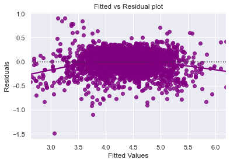

```python
# plotting the fitted values vs residuals

sns.residplot(
    data=df_pred, x="Fitted Values", y="Residuals", color="purple", lowess=True
)
plt.xlabel("Fitted Values")
plt.ylabel("Residuals")
plt.title("Fitted vs Residual plot")
plt.show()
```

Observations: The scatter plot shows the distribution of residuals (errors) vs fitted values (predicted values). There does not exist any pattern in this plot, so the model is linear and residuals are independent. We see no pattern in the plot above. Hence, the assumptions of linearity and independence are satisfied.

# TEST FOR NORMALITY

TEST FOR NORMALITY

- We will test for normality by checking the distribution of residuals, by checking the Q-Q plot of residuals, and by using the Shapiro-Wilk test.
- If the residuals follow a normal distribution, they will make a straight line plot, otherwise not.
- If the p-value of the Shapiro-Wilk test is greater than 0.05, we can say the residuals are normally distributed

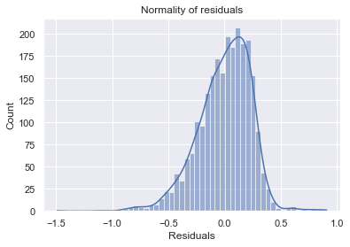

```python
# plotting the histogram of residuals
sns.histplot(data=df_pred, x="Residuals", kde=True)
plt.title("Normality of residuals")
plt.show()
```

Observations: The histogram of residuals does have a normal distribution so we check the Q-Q plot

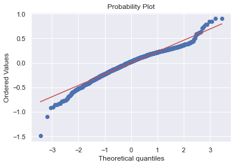

```python
# To check the Q-Q plot
import pylab
import scipy.stats as stats

stats.probplot(df_pred["Residuals"], dist="norm", plot=pylab)
plt.show()
```

Observations: The residuals more or less follow a straight line except for the tails. So we check the results of the Shapiro-Wilk test.

```python
# To check the results of the Shapiro-Wilk test
stats.shapiro(df_pred["Residuals"])
```

```
ShapiroResult(statistic=0.9706254601478577, pvalue=7.519403973211428e-22)
```

Observations: The p-value is 7.519403973211428e-22 which is less than 0.05. Thus the residuals are not normal as per the Shapiro-Wilk test. Strictly speaking, the residuals are not normal. However, as an approximation, we can accept this distribution as close to being normal. So, the assumption is satisfied.

# TEST FOR HOMOSCEDASTICITY

- We will test for homoscedasticity by using the goldfeldquandt test.
- If we get a p-value greater than 0.05, we can say that the residuals are homoscedastic. Otherwise, they are heteroscedastic.

```python
import statsmodels.stats.api as sms
from statsmodels.compat import lzip

name = ["F statistic", "p-value"]
test = sms.het_goldfeldquandt(df_pred["Residuals"], x_train3)
lzip(name, test)
```

```
[('F statistic', 1.006444493757842), ('p-value', 0.45584769735978026)]
```

Observations: Since p-value > 0.05, we can say that the residuals are homoscedastic. So, this assumption is satisfied.

# Predictions on test data

- Now that we have checked all the assumptions of linear regression and they are satisfied, let's go ahead with prediction.

```python
# predictions on the test set
pred = olsmod2.predict(x_test3)

df_pred_test = pd.DataFrame({"Actual": y_test, "Predicted": pred})
df_pred_test.sample(10, random_state=1)
```

|  | Actual | Predicted |
| --- | --- | --- |
| 1995 | 4.566741 | 4.396852 |
| 2341 | 3.696103 | 3.983638 |
| 1913 | 3.592093 | 3.609233 |
| 688 | 4.306495 | 4.078466 |
| 650 | 4.522115 | 5.110239 |
| 2291 | 4.259294 | 4.370564 |
| 40 | 4.997685 | 5.468065 |
| 1884 | 3.875359 | 4.017058 |
| 2538 | 4.206631 | 4.039892 |
| 45 | 5.380450 | 5.301533 |

Observations: The model has returned pretty good prediction results as the actual and predicted values are comparable

# Final Model Summary

```python
#
x_train_final = x_train3.copy()
x_test_final = x_test3.copy()
```

```python
# code to fit the final model
olsmodel_final = sm.OLS(y_train, x_train_final).fit()
print(olsmodel_final.summary())
```

```
                              OLS Regression Results
=================================================================================
Dep. Variable:     normalized_used_price   R-squared:                       0.839
Model:                               OLS   Adj. R-squared:                  0.838
Method:                    Least Squares   F-statistic:                     837.2
Date:                   Fri, 23 Feb 2024   Prob (F-statistic):               0.00
Time:                           12:28:34   Log-Likelihood:                 82.585
No. Observations:                   2417   AIC:                            -133.2
Df Residuals:                       2401   BIC:                            -40.53
Df Model:                             15
Covariance Type:               nonrobust
========================================================================================
                           coef    std err          t      P>|t|      [0.025      0.975]
----------------------------------------------------------------------------------------
const                    1.5550      0.048     32.071      0.000       1.460       1.650
main_camera_mp           0.0205      0.001     14.829      0.000       0.018       0.023
selfie_camera_mp         0.0137      0.001     12.711      0.000       0.012       0.016
ram                      0.0195      0.004      4.363      0.000       0.011       0.028
weight                   0.0017      6e-05     27.664      0.000       0.002       0.002
normalized_new_price     0.4375      0.011     38.954      0.000       0.415       0.460
years_since_release     -0.0303      0.003     -9.162      0.000      -0.037      -0.024
brand_name_LG           -0.0433      0.021     -2.020      0.043      -0.085      -0.001
brand_name_Micromax     -0.0550      0.028     -2.000      0.046      -0.109      -0.001
brand_name_Others       -0.0384      0.014     -2.664      0.008      -0.067      -0.010
brand_name_Samsung      -0.0514      0.017     -3.067      0.002      -0.084      -0.019
brand_name_Sony         -0.0684      0.031     -2.242      0.025      -0.128      -0.009
brand_name_Xiaomi        0.0771      0.026      2.993      0.003       0.027       0.128
os_Others               -0.1417      0.027     -5.264      0.000      -0.194      -0.089
os_iOS                  -0.0994      0.045     -2.198      0.028      -0.188      -0.011
4g_yes                   0.0458      0.015      3.018      0.003       0.016       0.076
==============================================================================
Omnibus:                      220.695   Durbin-Watson:                   1.897
Prob(Omnibus):                  0.000   Jarque-Bera (JB):              409.910
Skew:                          -0.618   Prob(JB):                     9.75e-90
Kurtosis:                       4.594   Cond. No.                     2.27e+03
==============================================================================

Notes:
[1] Standard Errors assume that the covariance matrix of the errors is correctly specified.
[2] The condition number is large, 2.27e+03. This might indicate that there are
strong multicollinearity or other numerical problems.
```

Observations: - If the size of the main_camera_mp increases by one unit, then its normalized used price increases by 0.0205 units when all other variables held constant - If the size of the selfie_camera_mp increases by one unit, then its normalized used price increases by 0.0137 units when all other variables held constant - If the size of the ram increases by one unit, then its normalized used price increases by 0.0195 units when all other variables held constant - If the size of the weight increases by one unit, then its normalized used price increases by 0.0017 units when all other variables held constant - If the size of the normalized_new_price increases by one unit, then its normalized used price increases by 0.4375 units when all other variables held constant - If the size of the years_since_release increases by one unit, then its normalized used price reduces by 0.0303 units when all other variables held constant - If the brand name increases by one unit, then its normalized used price reduces by - 0.0433 LG - 0.0550 Micromax- 0.0384 others brand names - 0.0514 Samsung- 0.0684 Sony units but increases by 0.0771 units of brand_name_Xiaomi when all other variables held constant - If the size of the other OS increases by one unit, then its normalized used price reduce by 0.1417 units when all other variables held constant - If the size of the os_iOS increases by one unit, then its normalized used price reduce by 0.0994 units when all other variables held constant - If the phone has 4G, then its normalized used price increases by 0.0458 units when all other variables held constant

```python
# checking model performance on train set (seen 70% data)
print("Training Performance\n")
olsmodel_final_train_perf = model_performance_regression(
    olsmodel_final, x_train_final, y_train
)
olsmodel_final_train_perf
```

```
Training Performance
```

|  | RMSE | MAE | R-squared | Adj. R-squared | MAPE |
| --- | --- | --- | --- | --- | --- |
| 0 | 0.233843 | 0.182808 | 0.839498 | 0.838428 | 4.392176 |

```python
# checking model performance on test set (seen 30% data)
print("Test Performance\n")
olsmodel_final_test_perf = model_performance_regression(
    olsmodel_final, x_test_final, y_test
)
olsmodel_final_test_perf
```

```
Test Performance
```

|  | RMSE | MAE | R-squared | Adj. R-squared | MAPE |
| --- | --- | --- | --- | --- | --- |
| 0 | 0.241224 | 0.185969 | 0.838669 | 0.836138 | 4.541137 |

Observations: The model is able to explain 83.9% of the variation in the data. The train and test RMSE and MAE are low and comparable and so our model is not suffering from overfitting. The MAPE on the test set suggests we can predict within 4.54% of the normalized used price of the used devices. Hence, the model olsmodel_final is good for prediction as well as inference purposes.